# BBC News Classification Mini-Project

```python
 # Load libraries
import pandas as pd
import numpy as np
import matplotlib.pyplot as plt
import seaborn as sns
from sklearn.feature_extraction.text import TfidfVectorizer
from wordcloud import WordCloud
import re
import itertools
from sklearn.metrics import accuracy_score, confusion_matrix
from sklearn.decomposition import NMF
from sklearn.linear_model import LogisticRegression
```

## Exploratory data analysis

### Load and clean data

The first step in this process is to load the datasets provided in the Kaggle competition files and perform some cleaning and visualizations. I check the training and test datasets for any missing values, of which there were none. However, the training dataset did have 50 duplicate articles, so I removed these to prevent their introducing any bias to the models. I also checked the number of articles in each category in the training dataset, since accuracy may not have been the best measure of model performance if the data was heavily skewed toward one category. Luckily, the articles in the dataset are relatively evenly distributed across the categories.

```python
# Load data
train = pd.read_csv('BBC News Train.csv')
test = pd.read_csv('BBC News Test.csv')
train.head()
```

|  | ArticleId | Text | Category |
| --- | --- | --- | --- |
| 0 | 1833 | worldcom ex-boss launches defence lawyers defe... | business |
| 1 | 154 | german business confidence slides german busin... | business |
| 2 | 1101 | bbc poll indicates economic gloom citizens in ... | business |
| 3 | 1976 | lifestyle governs mobile choice faster bett... | tech |
| 4 | 917 | enron bosses in $168m payout eighteen former e... | business |

```python
# Check for null values and duplicates - no null values but 50 duplicated articles
print(train.isnull().sum().sum(), test.isnull().sum().sum(), train.duplicated(subset=['Text']).sum())

# Drop duplicate observations
train = train.drop_duplicates(subset=['Text'])

# Check duplicates again
print(train.duplicated(subset=['Text']).sum())
```

```
0 0 50
0
```

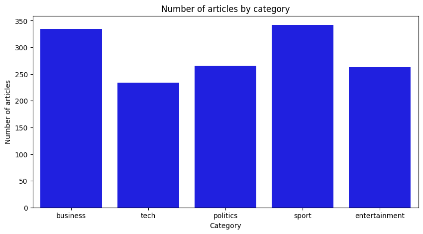

```python
# Plot number of articles by category
plt.figure(figsize=(10,5))
sns.countplot(x='Category', data=train, color='blue')
plt.xlabel('Category')
plt.ylabel('Number of articles')
plt.title('Number of articles by category')
plt.show()
```

### Check article text format

```python
# Check article text format
train['Text'][0]
```

```
'worldcom ex-boss launches defence lawyers defending former worldcom chief bernie ebbers against a battery of fraud charges have called a company whistleblower as their first witness.  cynthia cooper  worldcom s ex-head of internal accounting  alerted directors to irregular accounting practices at t…
```

```python
# Remove punctuation and special characters from article text
train['Text'] = [re.sub(r'[^\w\s]', '', text) for text in train['Text']]

# Check results
train['Text'][0]
```

```
'worldcom exboss launches defence lawyers defending former worldcom chief bernie ebbers against a battery of fraud charges have called a company whistleblower as their first witness  cynthia cooper  worldcom s exhead of internal accounting  alerted directors to irregular accounting practices at the …
```

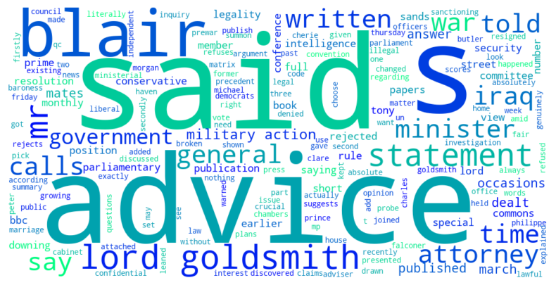

```python
# Word cloud of most frequent words
wordcloud = WordCloud(width=1000, height=500, background_color='white', colormap='winter').generate(train['Text'][10])

plt.figure(figsize=(10,5))
plt.imshow(wordcloud, interpolation='bilinear')
plt.axis('off')
plt.show()
```

### Natural language processing with TF-IDF

As shown in the above word cloud, while there are some frequent words in an article that are unique to the article or category, there are also some common words that will likely be frequent in any given article. One example is the word "said", which will be popular across categories of news articles because of the frequent inclusion of interview quotations. To combat this potential problem, I use the Term Frequency-Inverse Document Frequency (TF-IDF) method. This method converts strings into a matrix, where each value is the frequency of a given word in the string normalized by the word's popularity across all strings. Because of this calculation, and the inclusion of the max_df parameter in the function below, very common words that could clutter the model are removed, and others are given a lower value to reflect their lower importance to the model.

```python
# Process data with TF-IDF
tfidf = TfidfVectorizer(analyzer='word', norm='l2', stop_words='english', max_df=0.7)
train_text = tfidf.fit_transform(train['Text'])
train_labels = train['Category']
print(train_text.shape)
```

```
(1440, 26954)
```

## Unsupervised learning model

For the unsupervised learning model, I am using sklearn's non-negative matrix factorization (NMF) method. The number of components is set to 5 because there are 5 categories of news articles in the dataset. I begin by creating a few helper functions to automate to process of assigning the categories based on the model's label results, predicting categories for new labels, and saving the test dataset results for submission to the Kaggle competition.

### Helper functions

```python
# Helper function to assign categories based on highest accuracy of predictions
def permute_label(df, pred):
    """
    df: training dataset
    pred: model prediction output
    returns best label permutation and accuracy score
    """
    # Initialize values
    best_label = None
    best_acc = 0
    df_labels = list(df.Category.unique())

    # Iterate through all permutations of category combinations
    for perm in itertools.permutations(df_labels):
        pred_map = [perm[i] for i in pred]
        acc = accuracy_score(df['Category'], pred_map)

        if acc > best_acc:
            best_label = [(df_labels.index(i), i) for i in perm]
            best_acc = acc

    # Return results
    return best_label, best_acc
```

```python
 # Helper function to predict labels for dataset
def predict_label(model, df, best_label):
    """
    model: trained nmf model
    df: test dataset
    best_label: best label permutation from permute_label function
    returns list of predicted labels
    """
    # Transform dataframe with TF-IDF
    df_text = tfidf.transform(df['Text'])

    # Predict values based on model and assign best labels
    pred = model.transform(df_text).argmax(axis=1)
    pred_map = [best_label[i][1] for i in pred]

    # Return results
    return pred_map
```

```python
# Helper function to save test predictions for submission to the competition
def save_predict(df, pred_map):
    """
    df: test dataset
    pred_map: list of predicted labels
    saves dataframe of predicted labels as csv for submission
    """
    df_pred = pd.DataFrame(columns=['ArticleId', 'Category'])
    df_pred['ArticleId'] = df['ArticleId']
    df_pred['Category'] = pred_map
    df_pred.to_csv('test_predictions.csv', index=False)
```

### Initial model building and comparison

I build the unsupervised models on the training data only, beginning with the default parameters and then adjusting to try different combinations that improve the accuracy of predictions for the training dataset. Then, I compare the models' training set accuracy to the test set accuracy obtained by submitting the predictions to the Kaggle competition, available in the summary table below.

*Note: To keep the file size lower and increase the readability and performance of this notebook, I only include the code for a couple models being trained below, but the results of significant models tested are recorded in the table. The 'Test Accuracy' column comes from submitting the model predictions for the test dataset to the Kaggle competition.*

Summary of model results:

| init | solver | beta_loss | Training Accuracy | Test Accuracy |
| --- | --- | --- | --- | --- |
| nndsvda | cd | frobenius | 90.76% | 92.79% |
| nndsvda | mu | frobenius | 90.63% | 92.38% |
| **nndsvda** | **mu** | **kullback-leibler** | **91.32%** | **95.10%** |

```python
# Specify parameters for NMF model - default parameters
nmf_model = NMF(n_components=5, random_state=59)

# Fit model and create predictions
nmf_model.fit(train_text)
pred = nmf_model.transform(train_text).argmax(axis=1)

# Assign labels based on prediction accuracy
best_label, best_acc = permute_label(train, pred)
print(best_acc)

# Map training dataset predictions to the best labels
train_map = [best_label[i][1] for i in pred]
labels = [label[1] for label in best_label]

# Predict test categories and save results
test_pred = predict_label(nmf_model, test, best_label)
# save_predict(test, test_pred)
```

```
0.9076388888888889
```

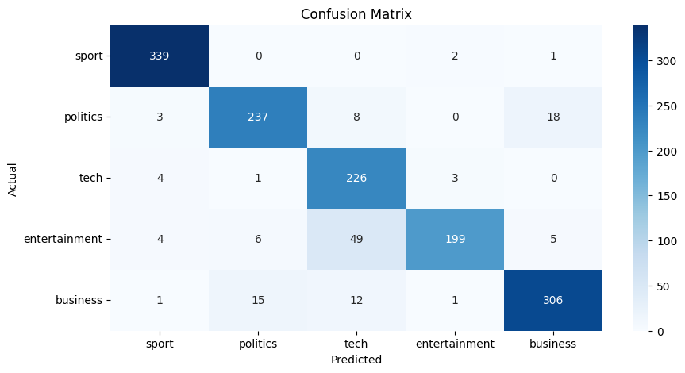

```python
# Create confusion matrix
cm = confusion_matrix(train_labels, train_map, labels=labels)

# Plot confusion matrix
plt.figure(figsize=(10,5))
sns.heatmap(cm, annot=True, fmt='d', cmap='Blues', xticklabels=labels, yticklabels=labels)
plt.xlabel('Predicted')
plt.ylabel('Actual')
plt.title('Confusion Matrix')
plt.show()
```

```python
# Testing additional models
# Specify parameters for NMF model
nmf_model = NMF(n_components=5, init='nndsvda', solver='mu', beta_loss='kullback-leibler', random_state=59)

# Fit model and create predictions
nmf_model.fit(train_text)
pred = nmf_model.transform(train_text).argmax(axis=1)

# Assign labels based on prediction accuracy
best_label, best_acc = permute_label(train, pred)
print(best_acc)

# Map training dataset predictions to the best labels
train_map = [best_label[i][1] for i in pred]
labels = [label[1] for label in best_label]

# Predict test categories and save results
test_pred = predict_label(nmf_model, test, best_label)
# save_predict(test, test_pred)
```

```
0.9131944444444444
```

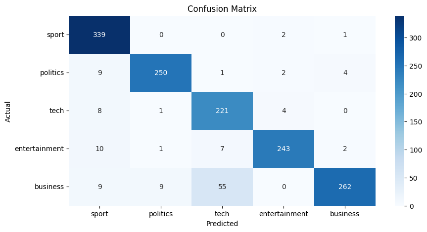

```python
# Map training dataset predictions to the best labels
train_map = [best_label[i][1] for i in pred]
labels = [label[1] for label in best_label]

# Create confusion matrix
cm = confusion_matrix(train_labels, train_map, labels=labels)

# Plot confusion matrix
plt.figure(figsize=(10,5))
sns.heatmap(cm, annot=True, fmt='d', cmap='Blues', xticklabels=labels, yticklabels=labels)
plt.xlabel('Predicted')
plt.ylabel('Actual')
plt.title('Confusion Matrix')
plt.show()
```

### Tuning model performance

*Note: To keep the file size lower and increase the readability and performance of this notebook, I only include the code for the final model being trained below, but the results of significant models tested are recorded in the table. The 'Test Accuracy' column comes from submitting the model predictions for the test dataset to the Kaggle competition.*

Summary of model results:

| max_df | min_df | ngram_range | Training Accuracy | Test Accuracy |
| --- | --- | --- | --- | --- |
| 0.7 | None | (1,1) | 91.32% | 95.10% |
| 0.8 | None | (1,1) | 91.32% | 95.10% |
| 0.9 | None | (1,1) | 91.39% | 95.24% |
| 0.9 | 5 | (1,1) | 95.49% | 95.10% |
| 0.9 | 4 | (1,1) | 95.20% | 95.37% |
| 0.9 | 3 | (1,1) | 94.51% | 95.51% |
| 0.9 | 2 | (1,1) | 94.58% | 95.65% |
| 0.9 | 2 | (1,2) | 93.75% | 95.92% |
| **0.9** | **2** | **(1,3)** | **94.86%** | **96.33%** |
| 0.9 | 2 | (1,4) | 94.65% | 96.33% |

```python
# Testing additional models with different text processing
tfidf = TfidfVectorizer(norm='l2', stop_words='english', max_df=0.9, min_df=2, ngram_range=(1,3))
train_text = tfidf.fit_transform(train['Text'])
train_labels = train['Category']

# Specify parameters for NMF model
nmf_model = NMF(n_components=5, init='nndsvda', solver='mu', beta_loss='kullback-leibler', random_state=59)

# Fit model and create predictions
nmf_model.fit(train_text)
pred = nmf_model.transform(train_text).argmax(axis=1)

# Assign labels based on prediction accuracy
best_label, best_acc = permute_label(train, pred)
print(best_acc)

# Map training dataset predictions to the best labels
train_map = [best_label[i][1] for i in pred]
labels = [label[1] for label in best_label]

# Predict test categories and save results
test_pred = predict_label(nmf_model, test, best_label)
# save_predict(test, test_pred)
```

```
0.9486111111111111
```

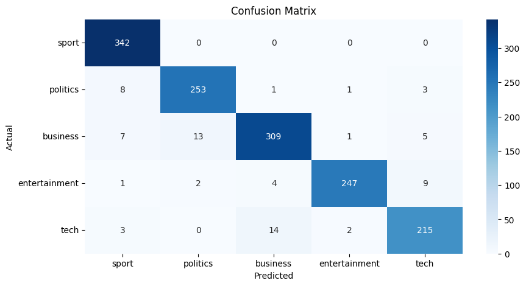

```python
# Map training dataset predictions to the best labels
train_map = [best_label[i][1] for i in pred]
labels = [label[1] for label in best_label]

# Create confusion matrix
cm = confusion_matrix(train_labels, train_map, labels=labels)

# Plot confusion matrix
plt.figure(figsize=(10,5))
sns.heatmap(cm, annot=True, fmt='d', cmap='Blues', xticklabels=labels, yticklabels=labels)
plt.xlabel('Predicted')
plt.ylabel('Actual')
plt.title('Confusion Matrix')
plt.show()
```

```python
# Save components as dataframe
components = pd.DataFrame(nmf_model.components_, columns=tfidf.get_feature_names_out())

# Display top words for each category
for category in range(components.shape[0]):
    top_words = components.iloc[category]
    print(f'For {best_label[category][1]} articles, the top words are:')
    print(top_words.nlargest(5))
    print('\n')
```

```
For sport articles, the top words are:
england    0.307833
game       0.295144
said       0.254530
win        0.239248
cup        0.221199
Name: 0, dtype: float64


For politics articles, the top words are:
mr          0.568879
labour      0.403099
said        0.399711
election    0.350413
blair       0.343975
Name: 1, dtype: float64


For business articles, the top words are:
said       0.398895
growth     0.277683
market     0.251734
year       0.244548
economy    0.242676
Name: 2, dtype: float64


For entertainment articles, the top words are:
film      0.607056
best      0.330006
awards    0.242022
band      0.220597
said      0.218062
Name: 3, dtype: float64


For tech articles, the top words are:
people        0.329092
mobile        0.308827
said          0.305674
users         0.244353
technology    0.241229
Name: 4, dtype: float64
```

## Supervised learning model

To compare to the results of the unsupervised models above, I am also modeling the data using a supervised learning technique, multi-class logistic regression. I chose this regression type because the response variable is a discrete group of five categories rather than being a continuous numeric variable.

*Note: To keep the file size lower and increase the readability and performance of this notebook, I only include the code for one model being trained below, but the results of significant models tested are recorded in the table. The 'Test Accuracy' column comes from submitting the model predictions for the test dataset to the Kaggle competition.*

Summary of model results:

| % of Training Labels | Training Accuracy | Test Accuracy |
| --- | --- | --- |
| **100%** | **99.79%** | **98.37%** |
| 50% | 100% | 97.14% |
| 10% | 100% | 88.16% |

```python
# Testing logistic regression with reduced training set
tfidf = TfidfVectorizer(norm='l2', stop_words='english', max_df=0.9, min_df=2, ngram_range=(1,3))

# Reduce the size of training set
train_reduced = train.sample(frac=0.5, random_state=59)
train_text_reduced = tfidf.fit_transform(train_reduced['Text'])
train_labels_reduced = train_reduced['Category']
test_text = tfidf.transform(test['Text'])

# Fit logistic regression model
log_model = LogisticRegression(multi_class='multinomial', random_state=59)
log_model.fit(train_text_reduced, train_labels_reduced)
pred = log_model.predict(train_text_reduced)
print(accuracy_score(train_labels_reduced, pred))

# Predict test categories and save results
test_pred = log_model.predict(test_text)
# save_predict(test, test_pred)
```

```
1.0
```

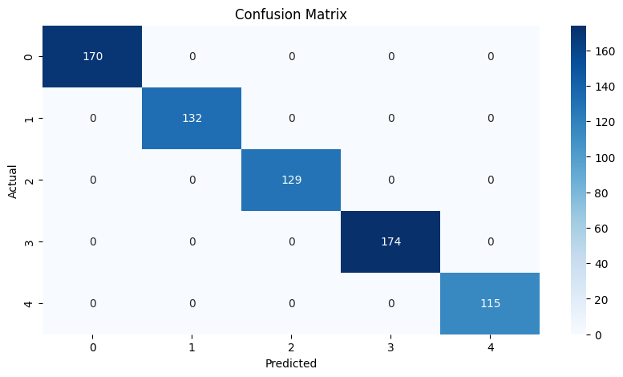

```python
# Create confusion matrix
cm = confusion_matrix(train_labels_reduced, pred)

# Plot confusion matrix
plt.figure(figsize=(10,5))
sns.heatmap(cm, annot=True, fmt='d', cmap='Blues')
plt.xlabel('Predicted')
plt.ylabel('Actual')
plt.title('Confusion Matrix')
plt.show()
```

## References

[1] Bose, Bijoy. "BBC News Classification Competition." Kaggle. March 2, 2019. https://www.kaggle.com/competitions/learn-ai-bbc/overview

[2] Kachkach, Ahmed. "Problem-solving with ML: automatic document classification." Google. Jan. 10, 2018. https://cloud.google.com/blog/products/ai-machine-learning/problem-solving-with-ml-automatic-document-classification

[3] Madan, Rohit. "TF-IDF/Term Frequency Technique." Medium. May 30, 2019. https://medium.com/analytics-vidhya/tf-idf-term-frequency-technique-easiest-explanation-for-text-classification-in-nlp-with-code-8ca3912e58c3